# Urdu words Classification from audio files using CNN

#### *Tried other modeling approaches as well but the results were not as great. The results of these techniques are mentioned in the Comments section of Task 6 below.*

[figure not shown]

### To build a model for different language word detection.

## Import Libraries

```python
from IPython.display import Audio
import numpy as np # linear algebra
import pandas as pd # data processing, CSV file I/O (e.g. pd.read_csv)
import matplotlib.pyplot as plt
import seaborn as sns
import re
import librosa
import librosa.display
from sklearn.preprocessing import minmax_scale

import matplotlib.pyplot as plt
from matplotlib import style
style.use("ggplot")

from sklearn.preprocessing import LabelEncoder
import IPython.display as ipd
import plotly as py
import tensorflow as tf
from sklearn.model_selection import train_test_split
from sklearn.metrics import accuracy_score, log_loss, confusion_matrix
import plotly.graph_objs as go
import tensorflow as tf
from tensorflow.keras.models import Sequential
from tensorflow.keras.layers import InputLayer, Conv2D, MaxPooling2D, Dense, Flatten
from tensorflow.keras.callbacks import EarlyStopping, ModelCheckpoint
from sklearn.preprocessing import StandardScaler
from sklearn.model_selection import train_test_split
from sklearn.metrics import classification_report, confusion_matrix, roc_auc_score, roc_curve, recall_score

import tensorflow as tf
from tensorflow.keras.models import Sequential
from tensorflow.keras.layers import InputLayer, Conv2D, MaxPooling2D, Dense, Flatten
from tensorflow.keras.callbacks import EarlyStopping, ModelCheckpoint

from sklearn.metrics import accuracy_score,log_loss, confusion_matrix,ConfusionMatrixDisplay

import warnings
warnings.filterwarnings("ignore")

import os
```

### Dataset contains a total of 2500 audio files of males and females, choose any 15 words out of available corpus (in PDF) for each available speaker. Please do mention the selected words in your solution notebook.

## The selected words with their index numbers from the Corpus and English Transliteration are:

### درمیانہ 1 (Darmyaana- 229)

### آپ 2 (Aap- 42)

### تمام 3 (Tamaam- 67)

### گھر 4 (Ghar-92)

### آج 5 (Aaj- 141)

### 6 کام (Kaam- 239)

### ادب 7 (Adab- 250)

### رات 8 (Raat- 22)

### شام 9 (Shaam- 21 )

### ہم 10 (Hum- 40)

### کیا 11 (Kya- 48)

### مگر 12 (Magar- 95)

### سال 13 (Saal- 58)

### پاس 14 (Paas- 96)

### خاص 15 (Khaas -147)

## Task 1. Prepare the dataframe containing selected words and audio file path.

[figure not shown]

```python
dirname = '../input/urdu-speech-dataset/files'
```

```python
urdu_words = ['درمیانہ  (Darmyaana- 229)', 'آپ  (Aap- 42)',' تمام  (Tamaam- 67)' ,
              'گھر 4 (Ghar-92)' , 'آج 5 (Aaj- 141)' , '6 کام (Kaam- 239)',
              'ادب 7 (Adab- 250)',  ' رات 8 (Raat- 22)',' شام 9 (Shaam- 21 )',' ہم 10 (Hum- 40)',
              'کیا 11 (Kya- 48)','مگر 12 (Magar- 95)',' سال 13 (Saal- 58)',' پاس 14 (Paas- 96)',' خاص 15 (Khaas -147)']
#Urdu word list

index_in_corpus = ['229','042','067','092','141','239','250','022','021','040','048','095','058','096','147']
#index of each urdu word from corpus

d = pd.DataFrame(columns=['Index in Corpus','Urdu Words','Speakers'])
```

```python
d['Index in Corpus'] = index_in_corpus
d['Urdu Words']= urdu_words
```

#### Repeating the same words 10 times for each speaker.

```python
d=pd.concat([d]*10, ignore_index=True)
d.head(20)
```

|  | Index in Corpus | Urdu Words | Speakers |
| --- | --- | --- | --- |
| 0 | 229 | درمیانہ (Darmyaana- 229) | NaN |
| 1 | 042 | آپ (Aap- 42) | NaN |
| 2 | 067 | تمام (Tamaam- 67) | NaN |
| 3 | 092 | گھر 4 (Ghar-92) | NaN |
| 4 | 141 | آج 5 (Aaj- 141) | NaN |
| 5 | 239 | 6 کام (Kaam- 239) | NaN |
| 6 | 250 | ادب 7 (Adab- 250) | NaN |
| 7 | 022 | رات 8 (Raat- 22) | NaN |
| 8 | 021 | شام 9 (Shaam- 21 ) | NaN |
| 9 | 040 | ہم 10 (Hum- 40) | NaN |
| 10 | 048 | کیا 11 (Kya- 48) | NaN |
| 11 | 095 | مگر 12 (Magar- 95) | NaN |
| 12 | 058 | سال 13 (Saal- 58) | NaN |
| 13 | 096 | پاس 14 (Paas- 96) | NaN |
| 14 | 147 | خاص 15 (Khaas -147) | NaN |
| 15 | 229 | درمیانہ (Darmyaana- 229) | NaN |
| 16 | 042 | آپ (Aap- 42) | NaN |
| 17 | 067 | تمام (Tamaam- 67) | NaN |
| 18 | 092 | گھر 4 (Ghar-92) | NaN |
| 19 | 141 | آج 5 (Aaj- 141) | NaN |

```python
speakers = ['AAMNG1','ABMNG1','ACMNG2','AEFYG1','AFFYG1','AGMNG1','AHMNG1','AIMYG2','AJMNG2','AKMNG2']
#list of all the speakers
```

#### Filling Speakers column with each word's audio file wrt its index in Corpus and ".wav" extension

```python
for i in range(0,15):
    d.iloc[i, 2:] = speakers[0]+"/"+speakers[0]+ d.iloc[i,0] +".wav"
for i in range(15,30):
    d.iloc[i, 2:] = speakers[1]+"/"+speakers[1]+ d.iloc[i,0] +".wav"
for i in range(30,45):
    d.iloc[i, 2:] = speakers[2]+"/"+speakers[2]+ d.iloc[i,0] +".wav"
for i in range(45,60):
    d.iloc[i, 2:] = speakers[3]+"/"+speakers[3]+ d.iloc[i,0] +".wav"
for i in range(60,75):
    d.iloc[i, 2:] = speakers[4]+"/"+speakers[4]+ d.iloc[i,0] +".wav"
for i in range(75,90):
    d.iloc[i, 2:] = speakers[5]+"/"+speakers[5]+ d.iloc[i,0] +".wav"
for i in range(90,105):
    d.iloc[i, 2:] = speakers[6]+"/"+speakers[6]+ d.iloc[i,0] +".wav"
for i in range(105,120):
    d.iloc[i, 2:] = speakers[7]+"/"+speakers[7]+ d.iloc[i,0] +".wav"
for i in range(120,135):
    d.iloc[i, 2:] = speakers[8]+"/"+speakers[8]+ d.iloc[i,0] +".wav"
for i in range(135,150):
    d.iloc[i, 2:] = speakers[9]+"/"+speakers[9]+ d.iloc[i,0] +".wav"
```

```python
d.head()
```

|  | Index in Corpus | Urdu Words | Speakers |
| --- | --- | --- | --- |
| 0 | 229 | درمیانہ (Darmyaana- 229) | AAMNG1/AAMNG1229.wav |
| 1 | 042 | آپ (Aap- 42) | AAMNG1/AAMNG1042.wav |
| 2 | 067 | تمام (Tamaam- 67) | AAMNG1/AAMNG1067.wav |
| 3 | 092 | گھر 4 (Ghar-92) | AAMNG1/AAMNG1092.wav |
| 4 | 141 | آج 5 (Aaj- 141) | AAMNG1/AAMNG1141.wav |

```python
d['Speakers'] = d['Speakers'].apply(lambda x: os.path.join(dirname,x))


print("Dataset Prepared, Task 1 completed! \n")
```

```
Dataset Prepared, Task 1 completed!
```

```python
d.head()
```

|  | Index in Corpus | Urdu Words | Speakers |
| --- | --- | --- | --- |
| 0 | 229 | درمیانہ (Darmyaana- 229) | ../input/urdu-speech-dataset/files/AAMNG1/AAMN... |
| 1 | 042 | آپ (Aap- 42) | ../input/urdu-speech-dataset/files/AAMNG1/AAMN... |
| 2 | 067 | تمام (Tamaam- 67) | ../input/urdu-speech-dataset/files/AAMNG1/AAMN... |
| 3 | 092 | گھر 4 (Ghar-92) | ../input/urdu-speech-dataset/files/AAMNG1/AAMN... |
| 4 | 141 | آج 5 (Aaj- 141) | ../input/urdu-speech-dataset/files/AAMNG1/AAMN... |

## Task 1 is completed

## 2. Split the dataset into a training and validation set.

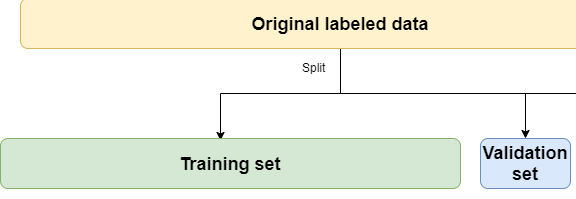

```python
d.isna().sum().sum()
```

```
0
```

#### *No null values as expected*

### Label Encoding the 15 words

```python
label_encoder = LabelEncoder()

d['Index in Corpus']= label_encoder.fit_transform(d['Index in Corpus'])

d['Index in Corpus'].unique()
```

```
array([12,  3,  6,  7, 10, 13, 14,  1,  0,  2,  4,  8,  5,  9, 11])
```

### Performing X and y division of dataset and dropping any unnecessary column

```python
df=d.copy() #for future use
X= d.drop(['Index in Corpus','Urdu Words' ], axis=1)
y=d['Index in Corpus']
```

```python
print("Shape of X = ", X.shape, y.shape)
```

```
Shape of X =  (150, 1) (150,)
```

```python
X_train, X_val, y_train, y_val = train_test_split(X, y, test_size=0.10, stratify=y)
```

```python
X_train.head()
```

|  | Speakers |
| --- | --- |
| 70 | ../input/urdu-speech-dataset/files/AFFYG1/AFFY... |
| 7 | ../input/urdu-speech-dataset/files/AAMNG1/AAMN... |
| 31 | ../input/urdu-speech-dataset/files/ACMNG2/ACMN... |
| 90 | ../input/urdu-speech-dataset/files/AHMNG1/AHMN... |
| 99 | ../input/urdu-speech-dataset/files/AHMNG1/AHMN... |

## Task 2 is completed.

## 3. Apply MFCC on those audio files.

```python
def mfcc_features_extract(x):

    features_mfcc = []
    try:
        x , sr = librosa.load(x)
        features_mfcc = librosa.feature.mfcc(y=x, sr=sr, n_mfcc=128)
        features_mfcc = np.mean(features_mfcc.T,axis=0)
    except:
        print('Error reading audio')
    return features_mfcc
```

```python
X_train= pd.DataFrame(X_train['Speakers'].apply(lambda a: mfcc_features_extract(a)).tolist())
```

```python
X_train
```

|  | 0 | 1 | 2 | 3 | 4 | 5 | 6 | 7 | 8 | 9 | ... | 118 | 119 | 120 | 121 | 122 | 123 | 124 | 125 | 126 | 127 |
| --- | --- | --- | --- | --- | --- | --- | --- | --- | --- | --- | --- | --- | --- | --- | --- | --- | --- | --- | --- | --- | --- |
| 0 | -250.764542 | 128.061905 | -54.549816 | 30.481483 | -2.080178 | 7.804188 | -14.654963 | 3.486200 | -9.218551 | -12.732119 | ... | 1.786488 | 0.426721 | -0.531601 | -0.565991 | 0.801533 | 0.518842 | 0.133078 | -0.130706 | -0.751656 | -0.179301 |
| 1 | -282.760162 | 153.298996 | -29.495819 | 37.791611 | -2.220346 | -4.087866 | -5.178446 | -11.735321 | -27.949535 | 21.505808 | ... | -0.580732 | 1.289996 | -0.440150 | -0.746658 | 2.003870 | 1.133857 | 0.846318 | 0.591256 | 1.135304 | -0.422045 |
| 2 | -297.208160 | 154.008881 | -14.983124 | 20.603010 | -45.981846 | -2.337897 | 5.116915 | 24.537329 | -25.717506 | -1.276556 | ... | 0.628875 | 0.786088 | -0.357184 | 0.020633 | 0.081802 | 0.062777 | -0.811875 | 0.018242 | -0.078558 | -0.999817 |
| 3 | -231.776230 | 151.678329 | -43.156204 | 48.591610 | 9.248057 | 5.533288 | 6.885214 | 1.592203 | -14.439162 | 6.767308 | ... | -0.149227 | -0.616005 | -1.805766 | -0.118493 | 0.213454 | 0.004747 | 0.052210 | 0.094165 | -0.465834 | -0.768604 |
| 4 | -307.412231 | 143.646408 | -16.716793 | 30.749664 | -3.200918 | 1.329234 | 21.092779 | 11.692014 | -0.233721 | -3.583677 | ... | 0.670753 | -0.350016 | -0.007214 | 0.019824 | -0.601751 | -0.370167 | 0.316708 | 0.334280 | 0.205879 | -0.568865 |
| ... | ... | ... | ... | ... | ... | ... | ... | ... | ... | ... | ... | ... | ... | ... | ... | ... | ... | ... | ... | ... | ... |
| 130 | -298.031555 | 196.195618 | -19.772470 | 13.295094 | -10.987487 | 10.242976 | 2.639816 | -1.785253 | -2.343152 | -9.894140 | ... | 0.561824 | -1.159181 | -1.576234 | -0.006235 | -0.440483 | -0.171834 | -0.343487 | -0.390686 | 1.080215 | 0.018233 |
| 131 | -267.983215 | 165.360580 | -17.059792 | 56.728943 | 1.945474 | 23.374620 | -18.033983 | 12.742813 | -23.972137 | 3.412813 | ... | -0.337374 | -0.332405 | -0.321377 | 0.856555 | 0.547973 | 0.577298 | 0.063689 | 0.452349 | 0.004162 | -0.069920 |
| 132 | -261.311279 | 136.704147 | -51.381027 | 31.507006 | -37.540775 | 19.124300 | -6.538931 | -7.756117 | -7.881327 | 8.155914 | ... | 0.290747 | 1.254936 | 0.570323 | 1.275271 | 1.376030 | -0.278234 | 1.251863 | 0.277235 | 0.070508 | -0.254554 |
| 133 | -269.482635 | 146.152359 | -17.996853 | 57.506512 | -11.074498 | 2.440470 | -14.239209 | -6.238955 | -1.345296 | -4.803691 | ... | 1.057911 | 0.679560 | 1.243085 | 0.512407 | 0.913243 | 1.559842 | 1.288118 | 1.156501 | 1.817009 | 0.423055 |
| 134 | -271.411957 | 121.879120 | -51.380173 | 19.115736 | -20.207140 | 25.085823 | -7.387415 | 10.977448 | 1.037910 | -11.478217 | ... | 1.027827 | 0.240011 | -0.375670 | 0.633997 | 0.371159 | 0.073060 | -0.519476 | 0.266183 | -0.179426 | -0.519456 |

135 rows × 128 columns

```python
X_val= pd.DataFrame(X_val['Speakers'].apply(lambda a: mfcc_features_extract(a)).tolist())
```

```python
X_val
```

|  | 0 | 1 | 2 | 3 | 4 | 5 | 6 | 7 | 8 | 9 | ... | 118 | 119 | 120 | 121 | 122 | 123 | 124 | 125 | 126 | 127 |
| --- | --- | --- | --- | --- | --- | --- | --- | --- | --- | --- | --- | --- | --- | --- | --- | --- | --- | --- | --- | --- | --- |
| 0 | -243.826614 | 181.563614 | -19.590874 | 41.655041 | 10.257900 | 13.762780 | -15.506510 | 11.582781 | -11.610483 | 5.764362 | ... | 0.073639 | 0.061365 | -0.414214 | 0.118563 | -0.111024 | -0.150438 | 0.260448 | -0.535480 | -0.192325 | -0.557889 |
| 1 | -208.934998 | 86.478462 | -46.518986 | 53.731449 | -60.984962 | 38.788410 | -6.894412 | 11.683997 | -13.889035 | -1.908354 | ... | -0.570096 | -0.596284 | -0.476475 | -0.084245 | -0.446285 | -0.243967 | -1.198636 | -0.835509 | -0.364839 | -0.453780 |
| 2 | -334.091736 | 148.418839 | 13.256168 | 22.807068 | -12.302592 | 23.157471 | 1.488340 | 13.279766 | -9.448071 | -9.618377 | ... | -0.636436 | -0.097711 | 0.015008 | 0.205746 | -0.597917 | -0.361891 | -0.041314 | -0.418185 | 0.290391 | 0.326191 |
| 3 | -285.193024 | 197.630829 | -15.660700 | 0.722375 | -46.922546 | 12.939904 | 10.789132 | -1.601244 | 2.103188 | -20.398975 | ... | -1.635408 | -0.114408 | 1.696215 | -0.524781 | -0.604179 | 1.041997 | 0.749959 | -0.633024 | 0.226833 | 0.813282 |
| 4 | -296.835449 | 144.807358 | -11.392790 | 38.658035 | 22.475687 | 9.105882 | -11.775262 | 2.640466 | -8.917905 | -6.995381 | ... | 1.148359 | 0.314958 | 0.176104 | -0.226556 | 0.335691 | 0.070049 | 0.319927 | -0.217491 | -0.181885 | 0.064532 |
| 5 | -269.151337 | 136.333694 | -34.135426 | 29.343672 | -24.965954 | 13.339447 | 7.700336 | 11.856772 | -5.258704 | -12.566864 | ... | 0.381500 | 0.172793 | -0.360609 | 0.125206 | 0.964509 | 0.046368 | 0.276223 | 0.131577 | 0.197827 | -0.885472 |
| 6 | -277.061462 | 166.387756 | -18.939636 | 27.387308 | 2.409072 | -2.924089 | -3.693425 | -22.134876 | -33.254280 | 2.870051 | ... | -0.069513 | -0.902915 | -0.495413 | 0.188569 | -0.315768 | -0.420841 | 0.589627 | 0.081920 | -0.556887 | 0.222213 |
| 7 | -243.875290 | 150.617004 | -30.491100 | 41.750954 | -16.802431 | 25.670561 | -16.192675 | 13.498237 | -22.817038 | -1.974795 | ... | -1.061905 | -0.337974 | -0.788578 | 0.300606 | 0.410273 | 0.203168 | 1.271370 | 0.235642 | 0.259506 | 0.221029 |
| 8 | -264.763428 | 164.915268 | -17.560278 | 34.436886 | -13.921775 | 18.088219 | -0.136846 | 8.637142 | -12.327213 | 6.898966 | ... | -0.855223 | -0.911007 | -0.381159 | -0.240201 | -0.333301 | 0.458187 | 0.512734 | -0.628150 | -0.400228 | 0.209573 |
| 9 | -211.293854 | 154.160828 | -44.051392 | 45.859138 | -5.299808 | 10.057203 | 8.246260 | -0.144055 | -19.956846 | -1.216333 | ... | 0.735722 | 0.208273 | -0.036719 | 0.112218 | -0.561751 | 0.472004 | 0.156527 | -0.634359 | 0.206998 | -1.097800 |
| 10 | -253.740463 | 202.786530 | -17.877712 | 6.151434 | -0.467368 | 7.399586 | 1.976938 | 33.105267 | -15.876980 | -1.194049 | ... | -0.482057 | -0.659949 | -0.489850 | -0.671172 | -0.230799 | 0.362430 | -0.143479 | -0.003650 | 0.070188 | -0.317382 |
| 11 | -243.873764 | 84.222771 | -60.386265 | 56.752884 | -37.748753 | 20.717846 | -9.509555 | -0.871732 | -10.473967 | -5.314285 | ... | 0.202699 | -0.414232 | -0.507231 | -0.306531 | -0.293841 | -0.122480 | -0.109171 | 0.339218 | -0.312656 | 0.152035 |
| 12 | -286.184845 | 129.913162 | -38.308395 | 3.295441 | 2.802738 | 16.222246 | -8.216521 | 1.026335 | -11.073947 | -21.523178 | ... | 0.902964 | 0.462412 | -1.456910 | -0.956493 | 1.287828 | -0.144902 | 0.103745 | -0.260606 | -1.193610 | 0.659891 |
| 13 | -234.920547 | 177.904358 | -42.267735 | 35.996616 | -6.459975 | 2.600619 | -11.971121 | 10.452168 | -20.436043 | 0.361533 | ... | 1.355553 | 0.067035 | -1.894009 | -0.633243 | 0.204478 | -0.004078 | 0.856062 | 0.490262 | 0.404759 | -1.240684 |
| 14 | -287.841248 | 208.093430 | -21.215355 | -5.545660 | -5.027130 | 7.473729 | -0.897983 | 4.576323 | -15.952520 | -7.104766 | ... | -0.088509 | -0.705929 | -1.113106 | 0.328304 | 0.405318 | -1.318995 | -1.439969 | 0.348757 | 1.308793 | -0.668522 |

15 rows × 128 columns

## Task 3 is completed.

## 4. Build a model to detect the words from the speech using MFCC features.

[figure not shown]

### Scaling and Reshaping

```python
std= StandardScaler()
X_train_scaled = std.fit_transform(X_train)
X_val_scaled = std.fit(X_val)
```

```python
X_train_scaled = X_train.values.reshape(X_train.shape[0], 16, 8, 1)
X_val_scaled = X_val.values.reshape(X_val.shape[0], 16, 8, 1)
```

```python
print("Shape of X_train and X_val: ", X_train_scaled.shape, X_val_scaled.shape)
```

```
Shape of X_train and X_val:  (135, 16, 8, 1) (15, 16, 8, 1)
```

### MODEL BUILDING

```python
tf.keras.backend.clear_session()
model = tf.keras.Sequential([
    tf.keras.layers.InputLayer(input_shape=(16, 8, 1)),
    tf.keras.layers.Conv2D(filters=32, kernel_size=(3, 3), activation='relu', padding = "same"),
    tf.keras.layers.MaxPooling2D(2, 2),
    tf.keras.layers.Conv2D(filters=8, kernel_size=(3, 3), activation='relu', padding = "same"),
    tf.keras.layers.MaxPooling2D(2, 2),
    tf.keras.layers.Flatten(),
    tf.keras.layers.Dense(32, activation='relu'),
    tf.keras.layers.Dense(len(d['Index in Corpus'].unique()), activation='softmax')
])
model.summary()
```

```
Model: "sequential"
_________________________________________________________________
Layer (type)                 Output Shape              Param #
=================================================================
conv2d (Conv2D)              (None, 16, 8, 32)         320
_________________________________________________________________
max_pooling2d (MaxPooling2D) (None, 8, 4, 32)          0
_________________________________________________________________
conv2d_1 (Conv2D)            (None, 8, 4, 8)           2312
_________________________________________________________________
max_pooling2d_1 (MaxPooling2 (None, 4, 2, 8)           0
_________________________________________________________________
flatten (Flatten)            (None, 64)                0
_________________________________________________________________
dense (Dense)                (None, 32)                2080
_________________________________________________________________
dense_1 (Dense)              (None, 15)                495
=================================================================
Total params: 5,207
Trainable params: 5,207
Non-trainable params: 0
_________________________________________________________________
```

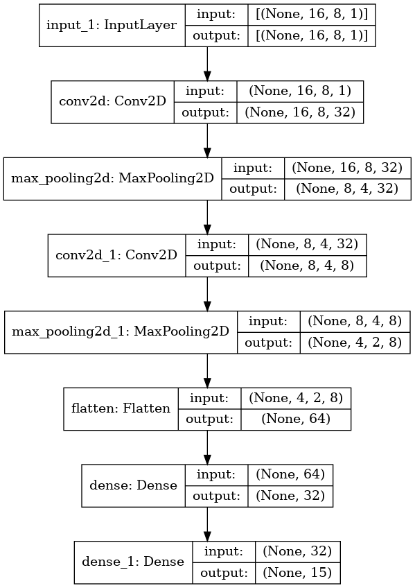

```python
tf.keras.utils.plot_model(model, show_shapes=True)
```

```python
model.compile(optimizer='adam', loss='sparse_categorical_crossentropy', metrics=['accuracy'])
```

```python
history = model.fit(X_train_scaled, y_train, epochs=200, validation_data=(X_val_scaled,y_val))
```

## Task 4 completed.

```python
# saving the model
#model.save("model_urdu.h5")
```

```python
# from keras.models import load_model

# load model
# model = load_model('model_urdu.h5')
```

## 5. Build the confusion matrix and F1-score on the validation set.

### Visualization

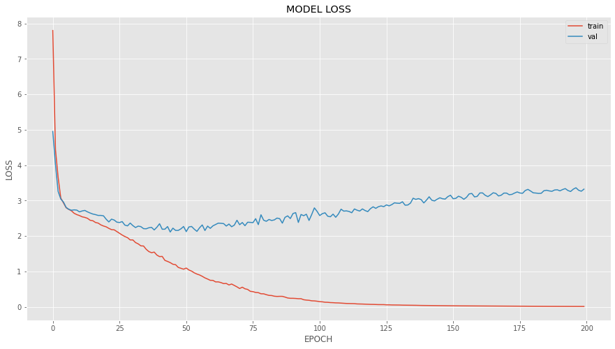

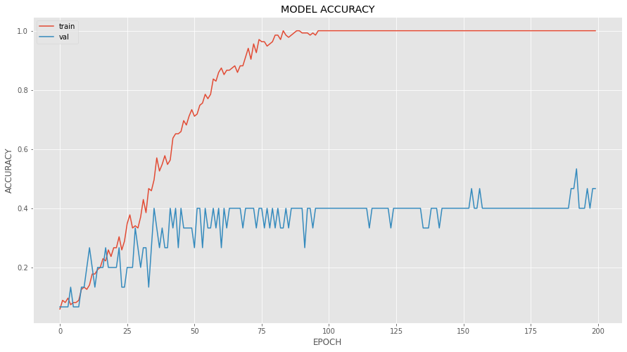

```python
plt.figure(figsize=(15,8))
plt.plot(history.history['loss'])
plt.plot(history.history['val_loss'])
plt.xlabel('EPOCH')
plt.ylabel('LOSS')
plt.title('MODEL LOSS')
plt.legend(['train', 'val'])
plt.show()

plt.figure(figsize=(15,8))
plt.plot(history.history['accuracy'])
plt.plot(history.history['val_accuracy'])
plt.xlabel('EPOCH')
plt.ylabel('ACCURACY')
plt.title('MODEL ACCURACY')
plt.legend(['train', 'val'])
plt.show()
```

```python
prob_val = model.predict(X_val_scaled)
pred_val = np.argmax(prob_val, axis=1)
pred_val = label_encoder.inverse_transform(pred_val)
```

```python
print("Testing Accuracy = ",accuracy_score(label_encoder.inverse_transform(y_val), pred_val)*100)
```

```
Testing Accuracy =  46.666666666666664
```

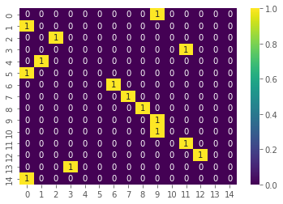

```python
sns.heatmap(confusion_matrix(label_encoder.inverse_transform(y_val), pred_val),cmap='viridis',annot=True,fmt='.3g')
```

```python
print(classification_report(label_encoder.inverse_transform(y_val), pred_val))
```

```
              precision    recall  f1-score   support

         021       0.00      0.00      0.00         1
         022       0.00      0.00      0.00         1
         040       1.00      1.00      1.00         1
         042       0.00      0.00      0.00         1
         048       0.00      0.00      0.00         1
         058       0.00      0.00      0.00         1
         067       1.00      1.00      1.00         1
         092       1.00      1.00      1.00         1
         095       1.00      1.00      1.00         1
         096       0.33      1.00      0.50         1
         141       0.00      0.00      0.00         1
         147       0.50      1.00      0.67         1
         229       1.00      1.00      1.00         1
         239       0.00      0.00      0.00         1
         250       0.00      0.00      0.00         1

    accuracy                           0.47        15
   macro avg       0.39      0.47      0.41        15
weighted avg       0.39      0.47      0.41        15
```

### Accuracy is 46.66%

### f1-score can be seen from classification report above

## Task 5 completed.

## 6. Record a sentence speaking atleast four words from the selected corpus, split the words from that sentence, test the model and provide your inference.

### Audio input

```python
Audio('../input/urduwords/urduwords_mine.mp4')
```

[interactive chart not shown]

### Spoke 4 words

[figure not shown]

```python
x , sr = librosa.load('../input/urduwords/urdumine.mp4')
plt.figure(figsize=(20, 5))
plt.title('Waveplot')
librosa.display.waveshow(x, sr=sr)
plt.show()
```

### We can see waveplots for 4 words.

```python
x.shape
```

```
(141591,)
```

```python
total_time = x.shape[0]/sr
per_window = x.shape[0]/total_time
total_time, per_window
```

```
(6.421360544217687, 22050.0)
```

### Word 1 - Aaj

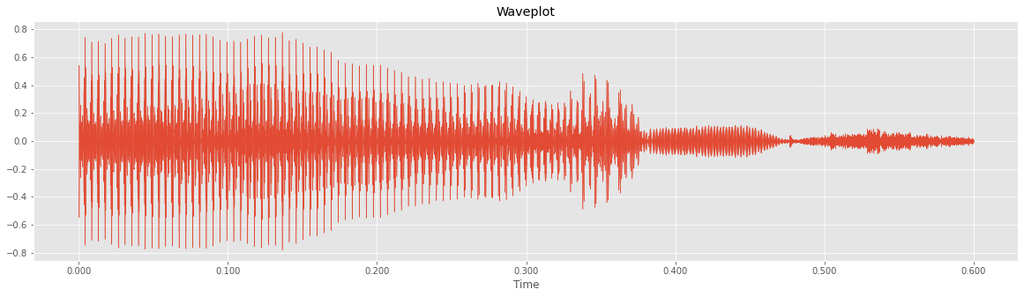

```python
x , sr = librosa.load('../input/urduwords/urduwords_mine.mp4')
plt.figure(figsize=(20, 5))
plt.title('Waveplot')
librosa.display.waveshow(x[int(0.8*per_window):int(1.4*per_window)], sr=sr)
plt.show()
```

```python
mfccs = librosa.feature.mfcc(y=x[int(0.8*per_window):int(1.4*per_window)], sr=sr, n_mfcc=128)
mfccs = np.mean(mfccs.T,axis=0)
mfccs.shape
```

```
(128,)
```

```python
X_test = mfccs.reshape(1, 16, 8, 1)
prob_val = model.predict(X_test)
pred_val = np.argmax(prob_val, axis=1)
pred_val = label_encoder.inverse_transform(pred_val)
```

```python
pred_val
```

```
array(['067'], dtype=object)
```

```python
Audio("../input/urdu-speech-dataset/files/AAMNG1/AAMNG1067.wav")
```

[interactive chart not shown]

### Word 2: Saal

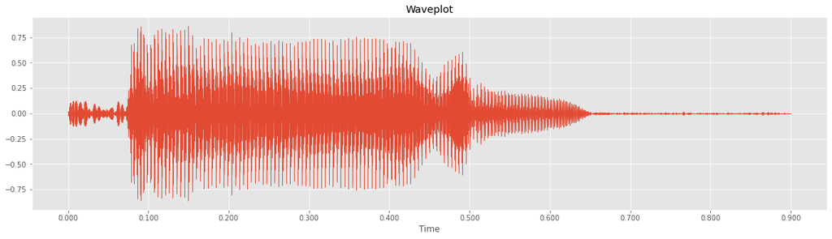

```python
x , sr = librosa.load('../input/urduwords/urduwords_mine.mp4')
plt.figure(figsize=(20, 5))
plt.title('Waveplot')
librosa.display.waveshow(x[int(2.4*per_window):int(3.3*per_window)], sr=sr)
plt.show()
```

```python
mfccs = librosa.feature.mfcc(y=x[int(2.4*per_window):int(3.3*per_window)], sr=sr, n_mfcc=128)
mfccs = np.mean(mfccs.T,axis=0)
mfccs.shape
```

```
(128,)
```

```python
X_test = mfccs.reshape(1, 16, 8, 1)
prob_val = model.predict(X_test)
pred_val = np.argmax(prob_val, axis=1)
pred_val = label_encoder.inverse_transform(pred_val)
```

```python
pred_val
```

```
array(['239'], dtype=object)
```

```python
Audio("../input/urdu-speech-dataset/files/AAMNG1/AAMNG1239.wav")
```

[interactive chart not shown]

### Word 3: Raat

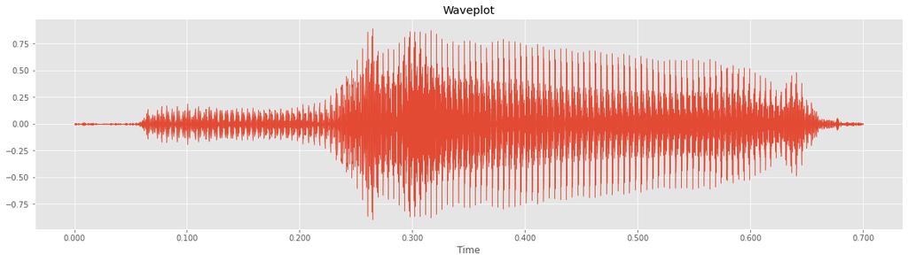

```python
x , sr = librosa.load('../input/urduwords/urduwords_mine.mp4')
plt.figure(figsize=(20, 5))
plt.title('Waveplot')
librosa.display.waveshow(x[int(3.8*per_window):int(4.5*per_window)], sr=sr)
plt.show()
```

```python
mfccs = librosa.feature.mfcc(y=x[int(3.8*per_window):int(4.5*per_window)], sr=sr, n_mfcc=128)
mfccs = np.mean(mfccs.T,axis=0)
mfccs.shape
```

```
(128,)
```

```python
X_test = mfccs.reshape(1, 16, 8, 1)
```

```python
prob_val = model.predict(X_test)
pred_val = np.argmax(prob_val, axis=1)
pred_val = label_encoder.inverse_transform(pred_val)
```

```python
pred_val
```

```
array(['229'], dtype=object)
```

```python
Audio("../input/urdu-speech-dataset/files/AAMNG1/AAMNG1229.wav")
```

[interactive chart not shown]

### Word 4: Kal

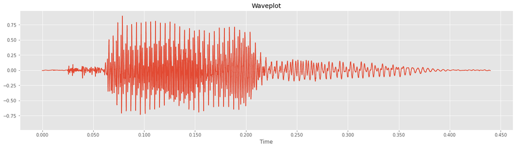

```python
x , sr = librosa.load('../input/urduwords/urduwords_mine.mp4')
plt.figure(figsize=(20, 5))
plt.title('Waveplot')
librosa.display.waveshow(x[int(5.46*per_window):int(5.9*per_window)], sr=sr)
plt.show()
```

```python
mfccs = librosa.feature.mfcc(y=x[int(5.46*per_window):int(5.9*per_window)], sr=sr, n_mfcc=128)
mfccs = np.mean(mfccs.T,axis=0)

mfccs.shape
```

```
(128,)
```

```python
X_test = mfccs.reshape(1, 16, 8, 1)
prob_val = model.predict(X_test)
pred_val = np.argmax(prob_val, axis=1)
pred_val = label_encoder.inverse_transform(pred_val)
pred_val
```

```
array(['229'], dtype=object)
```

```python
Audio("../input/urdu-speech-dataset/files/AAMNG1/AAMNG1229.wav")
```

[interactive chart not shown]

## Comments and Conclusion:

### **Tried different modeling approaches as:**

#### PCA, degraded accuracy and gave 20% accuracy with CNN

#### PCA and SVM(linear) degraded accuracy and gave app 6% accuracy

#### PCA and SVM(rbf) degraded accuracy and gave 0% accuracy

#### PCA and Decision Tree Classifier also degraded and gave 6.7% accuracy

#### PCA and RandomForest Classifier improved but still degraded and gave 6.7% accuracy

#### Scaled + PCA approach gave 0% or similar/same as above accuracy for all above models.

### Directly sending scaled X_train and X_val without PCA approach to Decision Tree gave 20% accuracy

#### Random Fiorest gave 13.3% accuracy for above

#### SVM(rbf) and SVM(linear) gave 0% accuracy for the same.

### Hence best accuracy was given by our CNN, giving 46% accuracy, which still is not that great.

## We might get better accuracy if we increase the size of our dataset.

## 7. Publish the solution notebook in that Kaggle dataset.